# Introduction to sovpal

```r
library(sovpal)
has_ggplot2 <- requireNamespace("ggplot2", quietly = TRUE)
has_jpeg    <- requireNamespace("jpeg", quietly = TRUE)
```

`sovpal` provides colour palettes from three Soviet sources: GOST industrial standards, military paint references, and avant-garde artworks. Several palettes are semantic. In GOST 14202-69, green denotes water, red fire suppression, and yellow flammable gas.

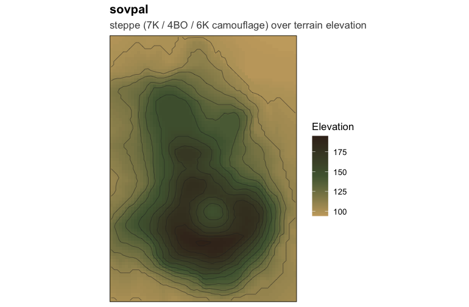

## Palettes by domain

Each palette has a thematic `domain` and a functional `type` (qualitative, sequential, or diverging).

```r
sovpal_palettes()
```

```
#>            palette     domain        type n_colors
#> 1        gost14202 industrial qualitative        8
#> 2      gost_signal industrial qualitative        4
#> 3             rust industrial  sequential        5
#> 4            steel industrial  sequential        5
#> 5           cobalt industrial  sequential        5
#> 6  soviet_military   military qualitative        6
#> 7           steppe   military  sequential        3
#> 8            field   military  sequential        5
#> 9        lissitzky   artistic qualitative        4
#> 10          popova   artistic qualitative        5
#> 11       stepanova   artistic qualitative        5
#> 12        malevich   artistic qualitative        5
#> 13          hazard  composite   diverging        3
#> 14     hazard_warm  composite   diverging        3
#> 15      hazard_cvd  composite   diverging        3
```

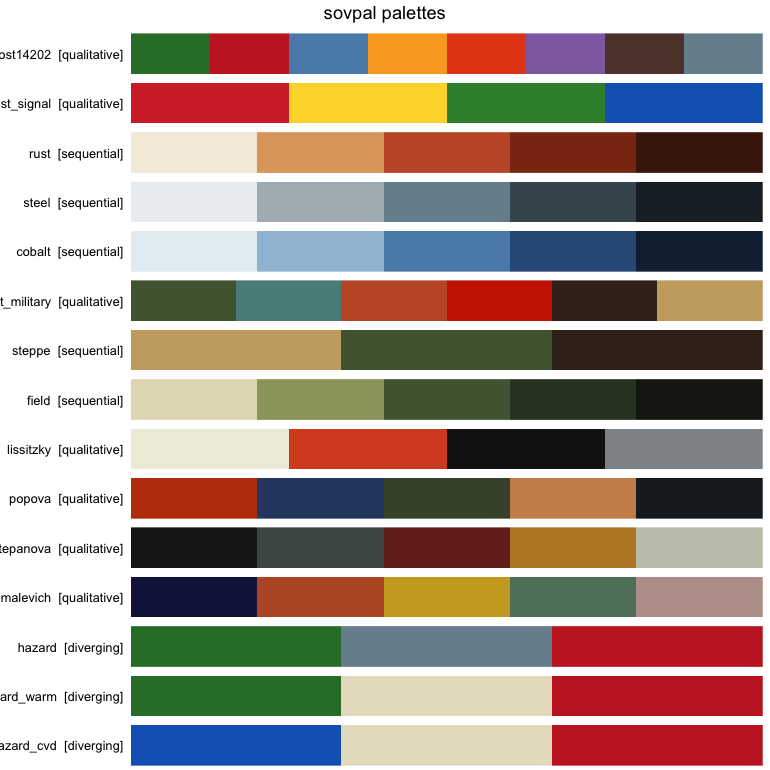

```r
show_all_palettes()
```

## Industrial

The GOST palettes are semantic. Because `sovpal()` returns a named vector, categories can be mapped to fixed colours with `scale_*_manual()`. The assignment is by name, so water is green and gas is yellow regardless of plotting order.

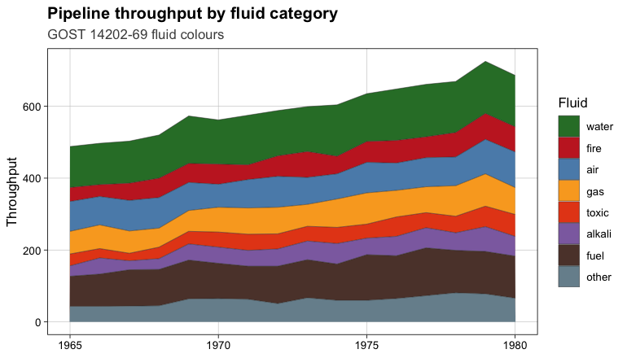

```r
set.seed(1969)
fluids <- names(sovpal("gost14202"))
flow <- expand.grid(year = 1965:1980, fluid = fluids)
flow$throughput <- round(abs(
  rep(c(120, 40, 70, 55, 25, 30, 90, 45), each = 16) +
    rep(seq(0, 30, length.out = 16), times = 8) +
    rnorm(nrow(flow), 0, 8)
))
flow$fluid <- factor(flow$fluid, levels = fluids)

ggplot(flow, aes(year, throughput, fill = fluid)) +
  geom_area(colour = "grey15", linewidth = 0.15) +
  scale_fill_manual(values = sovpal("gost14202")) +
  labs(title = "Pipeline throughput by fluid category",
       subtitle = "GOST 14202-69 fluid colours",
       x = NULL, y = "Throughput", fill = "Fluid")
```

## Military

`soviet_military` is a set of period vehicle and aircraft colours. `steppe` (shown above) is a camouflage terrain ramp.

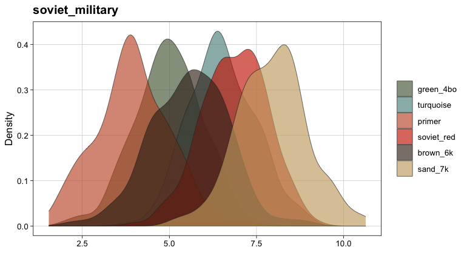

```r
set.seed(42)
classes <- names(sovpal("soviet_military"))
dens <- data.frame(
  value = c(rnorm(200, 5), rnorm(200, 6.5), rnorm(200, 4),
            rnorm(200, 7), rnorm(200, 5.5), rnorm(200, 8)),
  class = factor(rep(classes, each = 200), levels = classes)
)
ggplot(dens, aes(value, fill = class)) +
  geom_density(alpha = 0.65, colour = "grey15", linewidth = 0.2) +
  scale_fill_sovpal("soviet_military") +
  labs(title = "soviet_military", x = NULL, y = "Density", fill = NULL)
```

## Artistic

Each artistic palette is colour-sampled from a specific artwork and named for the artist, following the convention of the MetBrewer package. The hex values are approximate, sampled from reproductions. See `data-raw/sample_artwork.R`.

[figure not shown]

[figure not shown]

[figure not shown]

`stepanova` is sampled from Varvara Stepanova’s *Billiard Players* (1920), a cubo-futurist work in charcoal, slate, brick, gold, and khaki. The work is under copyright in the EU (Stepanova died in 1958), so the image is not bundled; the palette is shown below. [View the work at the Museo Thyssen-Bornemisza](https://www.museothyssen.org/en/collection/artists/stepanova-varvara/billiard-players).

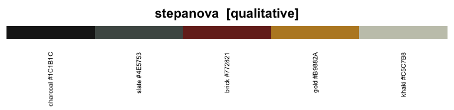

```r
show_palette("stepanova", notes = FALSE)
```

## Sequential ramps

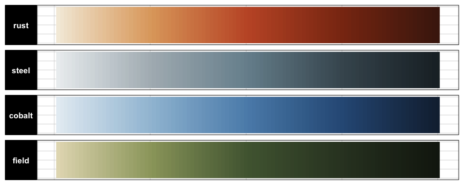

```r
seqs <- c("rust", "steel", "cobalt", "field")
ramp <- do.call(rbind, lapply(seqs, function(p)
  data.frame(pal = p, x = 1:100, fill = sovpal(p, n = 100, type = "continuous"))))
ramp$pal <- factor(ramp$pal, levels = seqs)

ggplot(ramp, aes(x, 1, fill = fill)) +
  geom_raster() +
  scale_fill_identity() +
  facet_wrap(~pal, ncol = 1, strip.position = "left") +
  labs(x = NULL, y = NULL) +
  theme(axis.text = element_blank(), axis.ticks = element_blank(),
        strip.text.y.left = element_text(angle = 0, face = "bold"),
        panel.grid = element_blank())
```

## Composite

The diverging palettes place the lightest colour at the midpoint. `hazard_warm` (green, cream, red) and `hazard_cvd` (blue, cream, red) use a light cream midpoint; `hazard_cvd` is intended for red-green colour vision deficiency. `hazard` (green, grey, red) retains the GOST source colours.

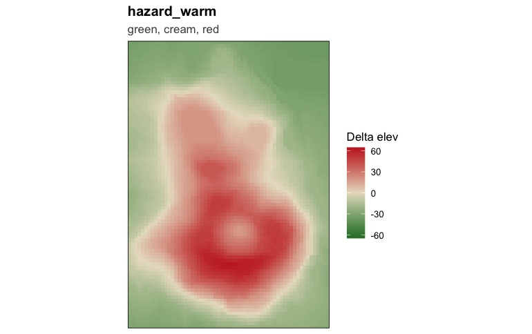

```r
v$centered <- v$elev - mean(v$elev)
lim <- max(abs(v$centered))
ggplot(v, aes(col, row, fill = centered)) +
  geom_raster() +
  scale_fill_sovpal("hazard_warm", discrete = FALSE,
                    limits = c(-lim, lim), name = "Delta elev") +
  coord_equal(expand = FALSE) +
  labs(title = "hazard_warm", subtitle = "green, cream, red") +
  theme(axis.title = element_blank(), axis.text = element_blank(),
        axis.ticks = element_blank())
```

## Usage

```r
# Retrieve a palette (named vector)
sovpal("malevich")
```

```
#>      navy       red      gold     green      rose
#> "#161B49" "#B9592F" "#CEA829" "#5D8169" "#BB9E99"
```

```r
# n colours, or interpolate a continuous ramp
sovpal("gost14202", n = 4)
```

```
#>     water      fire       air       gas
#> "#2E7D32" "#C62828" "#5B8DB8" "#F9A825"
```

```r
length(sovpal("steppe", n = 100, type = "continuous"))
```

```
#> [1] 100
```

```r
# Subset with base-R indexing
sovpal("gost14202")[c("water", "fire", "air")]
```

```
#>     water      fire       air
#> "#2E7D32" "#C62828" "#5B8DB8"
```

`palette_info()` reports the domain, provenance, recommended use, colour vision notes, and computed white-background contrast (WCAG ratio; 3:1 is the threshold for graphical objects). The off-white ground in `lissitzky` falls below the threshold and is listed in `low_contrast_on_white`.

```r
info <- palette_info("lissitzky")
info$source
```

```
#> [1] "Color-sampled from a reproduction of El Lissitzky, 'Beat the Whites with the Red Wedge' (1919). Approximate."
```

```r
info$contrast_white
```

```
#> [1]  1.18  4.15 18.59  3.10
```

```r
info$low_contrast_on_white
```

```
#> [1] "ground"
```

## Historical notes

GOST 14202-69 (pipeline identification), adopted in 1969, standardised the colour-coding of industrial pipelines across Soviet enterprises: eight base colours for fluid categories, referenced by paint card number.

GOST 12.4.026 (safety signage) defines four signal colours: red (danger), yellow (caution), green (safe), and blue (mandatory action).

4BO Protective Green (`#51653F`) was the standard Soviet vehicle exterior colour from the 1930s through the Cold War. The value is based on Vallejo 70.609. It appears in `soviet_military` and as the middle stop of `steppe`.